# Statistical Inference week2

### Variance

Var(x) = E[(x - mu)^2] = E[X^2] - E[x]^2

#### Sample variance

s^2 = Sigma(i-1) (x_i - x_bar) / n-1

This is also a random value, that should estimate the original variance  
If you sample enough and get the sample variance, it should center at the varience

Variance of 10 die rolls should be 2.92. If you do it enough, it will center around 2.92.

Why n-1? That makes it unbiased.

E(x_bar) = mu  
Var(x_bar) = sigma ^ 2 / n

Variance of the sample mean is s = sigma ^ 2 / n  
- The logical estimate is s^2/n - the logical estimate of the standard error is S/route(n)

```r
nosim <- 1000
n <- 10
sd(apply(matrix(rnorm(nosim * n), nosim), 1, mean))
```

```
## [1] 0.3147056
```

```r
# 1 indicates rows in a matrix
dim(matrix(rnorm(nosim * n), nosim))
```

```
## [1] 1000   10
```

```r
1/sqrt(n)
```

```
## [1] 0.3162278
```

Standard uniforms, a flat line, variance of 1/12

```r
nosim <- 1000
n <- 10
sd(apply(matrix(runif(nosim*n), nosim), 1, mean))
```

```
## [1] 0.0930455
```

```r
1 / sqrt(12 * n)
```

```
## [1] 0.09128709
```

Possion 4 has a variance of 4, sd should be 2/route(n)

```r
nosim <- 1000
n < 10
```

```
## [1] FALSE
```

```r
sd(apply(matrix(rpois(nosim * n, 4), nosim), 1, mean))
```

```
## [1] 0.6313142
```

```r
2/ sqrt(n)
```

```
## [1] 0.6324555
```

Coin flips, variance 0.25, should be 1/2sqrt(n)

```r
nosim <- 1000
n <- 10
sd(apply(matrix(sample(0:1, nosim * n, replace = T), nosim), 1, mean))
```

```
## [1] 0.1604568
```

```r
1/(2 * sqrt(n))
```

```
## [1] 0.1581139
```

data example

```r
library(UsingR); data(father.son);
```

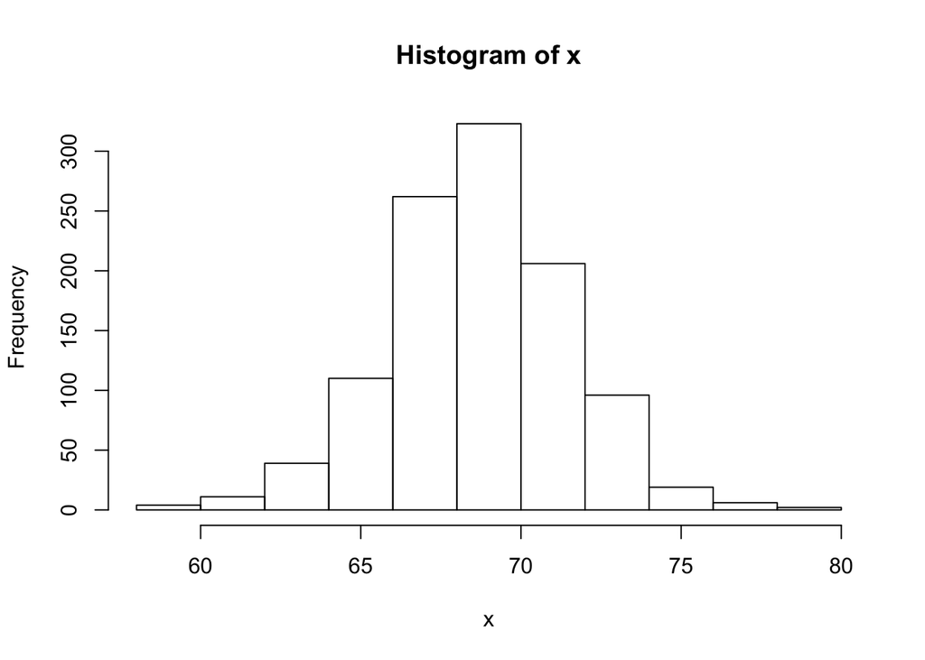

```r
x <- father.son$sheight
n <- length(x)
hist(x)
```

```r
round(c(var(x), var(x)/n, sd(x), sd(x)/sqrt(n)), 2)
```

```
## [1] 7.92 0.01 2.81 0.09
```

## Common distributions

### Bernoulli distribution

flipping a coin with prob = p  
mean : p  
variance: p(1-p)  
mass function: P(X = x) = p^x * (1 - p) ^ n-x

### Bionmial trials

total number of heads on a coin  
P(X = x) = nCx p^x * (1 - p)^n-x

7 are girls out of 8 children, what’s the probability of getting 7 or more

```r
choose(8,7) * .5 ^ 8 + choose(8,8) * .5^8
```

```
## [1] 0.03515625
```

```r
pbinom(6, size = 8, prob = .5, lower.tail = F)
```

```
## [1] 0.03515625
```

### Normal distruibution

E(x) = mu  
Var(x) = sigma ^ 2  
Written as X~N(mu, sigma)

mu = 0, sigma = 1 for a standard normal distruibution

All normal distruibutions are the same shape, just adjust mu and sigma  
[-1, 1] = 68%  
[-2, 2] = 95%  
[-3, 3] = 99%

X ~ N(mu, sigma) -> (X - mu)/sigma ~ N(0,1)  
X~N(0,1) -> mu + sigma * X ~ N(mu, sigma)

1. 68%, 95%, 99% are from 1,2,3 standard deviations from the mean
2. -1.28, -1.645, -1.96 and -2.33 are the 10th, 5th, 2.5th, 1st percentiles
3. 1.28, 1.645, 1.96 and 2.33 are the 90th, 95th, 97.5th and 99th percentiles

what’s the 95th quantile?

```r
qnorm(.95)
```

```
## [1] 1.644854
```

what’s the probability that N(mu, sigma^2) is larger than x  
pnorm(x, lower.tail = F) conceptualy, convert

say, 1020 clicks per day, 1160 clicks, v = 50 (1160 - 1020) / 50 = 2.8 so not very likely

```r
pnorm(1160, mean = 1020, sd = 50, lower.tail = F)
```

```
## [1] 0.00255513
```

```r
pnorm(2.8, lower.tail = F)
```

```
## [1] 0.00255513
```

quantile calculation, 75% of days have fewer clicks than 50% are lower than 1020 84% are lower than 1020 + 50

```r
qnorm(0.75, mean = 1020, sd = 50)
```

```
## [1] 1053.724
```

### Possion distribution

used to model counts  
P(X = x: lamda) = lamda^x * e(-lamda) / x!

mean: lambda variance: lambda

- modeling count data
- modeling contingency tables
- can be used when n is large and p is small

X ~ Possion(lamda * t)  
t is for time

2.5 people per hour at a bus stop, only saw 3 in 4 hours

```r
ppois(3, lambda = 2.5 * 4)
```

```
## [1] 0.01033605
```

X ~ Binomial(n,p)  
lambda = np  
n is large  
p is small

coin pecentage 0.01, 500 times 2 or few successs

```r
pbinom(2, size = 500, prob = 0.01)
```

```
## [1] 0.1233858
```

```r
ppois(2, lambda = 500 * 0.01)
```

```
## [1] 0.124652
```

## A trip to Asymtopia

Where you have an infinite amount of data  
Law of large numbers

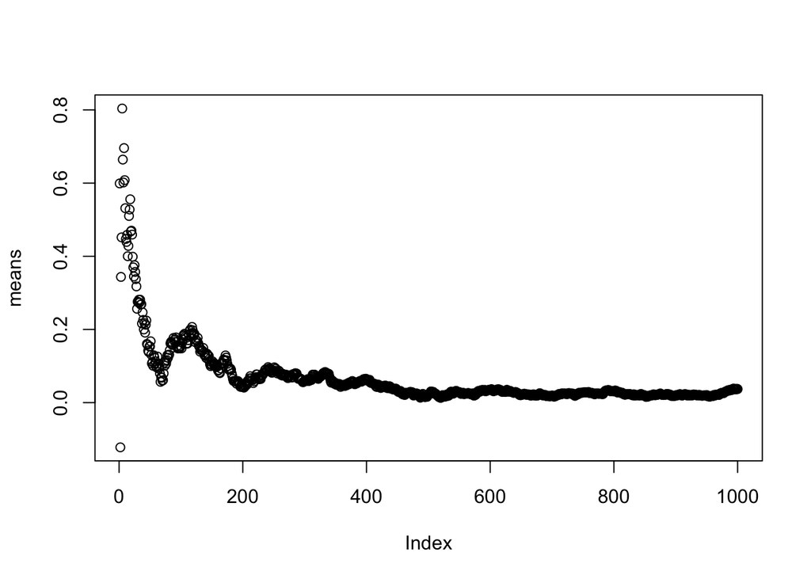

```r
n <- 1000
means <- cumsum(rnorm(n))/(1:n)
plot(means)
```

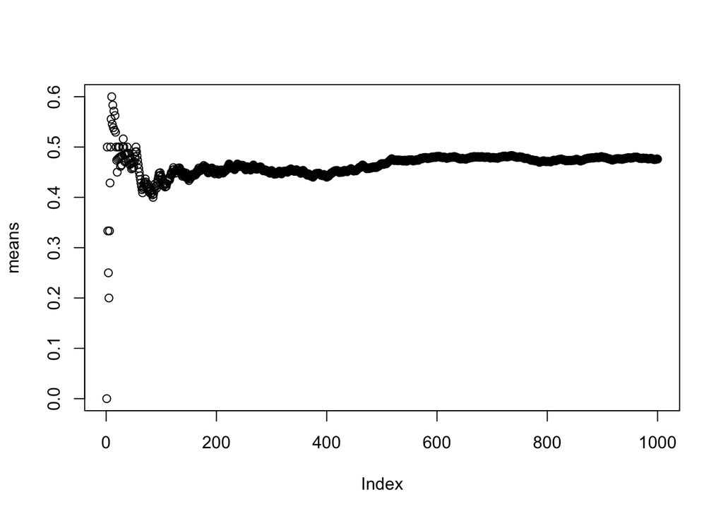

```r
means <- cumsum(sample(0:1, n, replace = T))/(1:n)
plot(means)
```

An estimator is consistent if it converges to what you what to estimate

### The central limit theorem

Estimate - Mean of estimate / Std. Err. of estimate  
has a distruibution like that of a standard normal for large n

e.g. standard die  
E(x) = 3.5  
V(x) = 2.92  
SE sqrt(2.92/n) = 1.71/sqrt(n)

it becomes a bell curve

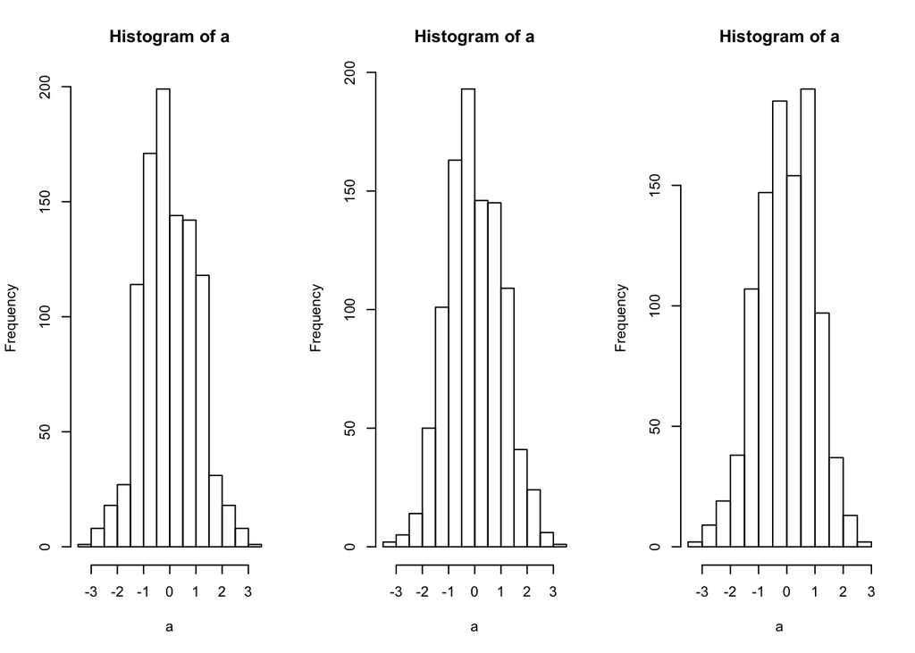

```r
n <- 10
nosim <- 1000
a <- integer(nosim)
for(i in 1:nosim){
        b <-  mean(ceil(runif(n, 0, 6)))
        a[i] <- (b - 3.5)/(1.71/sqrt(n))
}
par(mfrow=c(1,3))
hist(a)
n <- 20
for(i in 1:nosim){
        b <-  mean(ceil(runif(n, 0, 6)))
        a[i] <- (b - 3.5)/(1.71/sqrt(n))
}
hist(a)
n <- 30
for(i in 1:nosim){
        b <-  mean(ceil(runif(n, 0, 6)))
        a[i] <- (b - 3.5)/(1.71/sqrt(n))
}
hist(a)
```

#### use a coin

E(x) = p  
V(x) = p(1-p)  
SE sqrt(p(1-p)/n)

p^hat - p / sqrt(p(1-p)/n)

if the coin is biased, it ’ll take more time